# ANLY503_HW5_Xin_Lu_p1

Xin

10/19/2020

4. For the account with the highest number of transactions, make a time series line plot for the behavior of the account over time, including all debits and credits, the different methods, and the with the different categories.

```r
# install.packages("reticulate")
library(reticulate)
# use_virtualenv("myenv")
# system("virtualenv -p /usr/bin/python3 /home/andres/.virtualenvs/py3-virtualenv")
# virtualenv_create("py3-virtualenv", python = "/usr/bin/python3")
# use_virtualenv("py3-virtualenv")
# py_install("pandas", envname = "py3-virtualenv")
# https://community.rstudio.com/t/problem-installing-python-libraries-with-reticulate-py-install-error-pip-not-found/26561


# use_python("/usr/local/bin/python3", required = T)
# sys <- import("sys")
# sys$version

# create a conda environment
# conda_create('r-reticulate')

# check what conda environments are available
conda_list()
```

```
##           name                                                  python
## 1    anaconda3                   /Users/xinlu/opt/anaconda3/bin/python
## 2 r-reticulate /Users/xinlu/opt/anaconda3/envs/r-reticulate/bin/python
```

```r
# choose one conda environement to run python
use_python("/Users/xinlu/opt/anaconda3/envs/r-reticulate/bin/python", required = T)

# confirm the python environment has been changed to the one listed above
Sys.which("python")
```

```
##                                                    python
## "/Users/xinlu/opt/anaconda3/envs/r-reticulate/bin/python"
```

```r
use_condaenv("r-reticulate")

# install packages into the conda environment
# conda_install('r-reticulate', packages = 'numpy')
# check the package has been installed
py_module_available("numpy")
```

```
## [1] TRUE
```

```r
# conda_install('r-reticulate', packages = 'pandas')
# conda_install('r-reticulate', packages = 'matplotlib')
# conda_install('r-reticulate', packages = 'seaborn')
py_module_available("seaborn")
```

```
## [1] TRUE
```

```python
import pandas as pd
# import random
# import matplotlib.pyplot as plt
import numpy as np
import matplotlib.pyplot as plt
import seaborn as sns
```

```python
# accounts = pd.read_csv("data/accounts_analytical.csv")
# accounts.info()
transactions= pd.read_csv("data/transactions.csv")
transactions.info()
```

```
## <class 'pandas.core.frame.DataFrame'>
## RangeIndex: 1056320 entries, 0 to 1056319
## Data columns (total 10 columns):
##  #   Column      Non-Null Count    Dtype
## ---  ------      --------------    -----
##  0   id          1056320 non-null  int64
##  1   account_id  1056320 non-null  int64
##  2   date        1056320 non-null  object
##  3   type        1056320 non-null  object
##  4   amount      1056320 non-null  int64
##  5   balance     1056320 non-null  int64
##  6   bank        273508 non-null   object
##  7   account     295389 non-null   float64
##  8   method      873206 non-null   object
##  9   category    521006 non-null   object
## dtypes: float64(1), int64(4), object(5)
## memory usage: 80.6+ MB
```

First, I need to find the account with the highest number of transactions, which is account_id = 8261, and I extract all info from this account to expedite the processing time. Then I make sure the column data is in datetime format, and set as index. Next in order to distinguish debit from credit, I change debit to negative values.

```python
transactions['account_id'].value_counts().sort_values(ascending=False)
```

```
## 8261    675
## 3834    665
## 96      661
## 2932    655
## 9307    649
##        ...
## 1430     12
## 758      12
## 727      11
## 315      11
## 182       9
## Name: account_id, Length: 4500, dtype: int64
```

```python
transactions = transactions.loc[transactions['account_id'] == 8261]

# convert date from string to datetime
transactions['date'] = pd.to_datetime(transactions['date'])

# need to set date as index for time series plot
transactions = transactions.set_index('date').sort_index()

# update debit to negative values
# [ expression for item in list if conditional ]
transactions['amount'] = [(-1)*x if j == 'debit' else x for x,j in zip(transactions['amount'], transactions['type'])]

# show all the columns
# pd.set_option('display.max_columns', None)
# transactions.head(10)
# transactions.info()
```

From the debit and credit transaction of this account over time, we can see very clearly that the credit transactions behave very consistently over time, debit transactions on the other hand, behave kindly unpredictable over time with some very dramatic changes. The transactions kind of make sense because credit transactions can be regular deposits such as salaries or investments coming into banks, and debit transactions are withdrawal so they can vary depending on what the customer is purchasing.

From graph transactions of different categories, we can see some very consistent behaviors, such as the account has a two-year loan that pays the same amount from 1993 to 1995. The account also has a house payment that pays out the same amount every month starting from 1993.

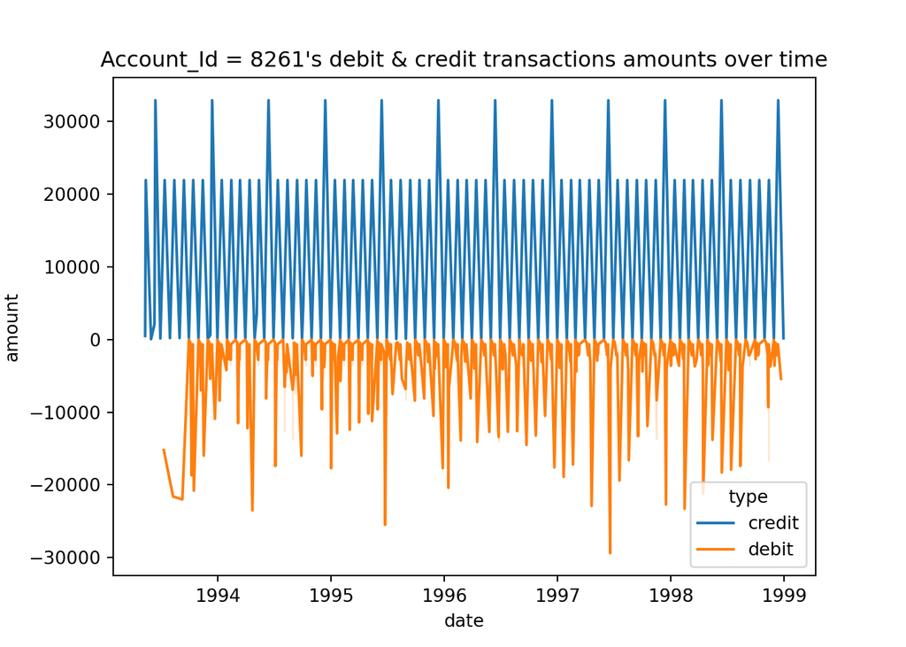

```python
plt.figure(5)
fig5 = sns.lineplot(x=transactions.index, y=transactions['amount'], data=transactions, hue=transactions['type'])
fig5.set_title("Account_Id = 8261's debit & credit transactions amounts over time")
plt.show()
```

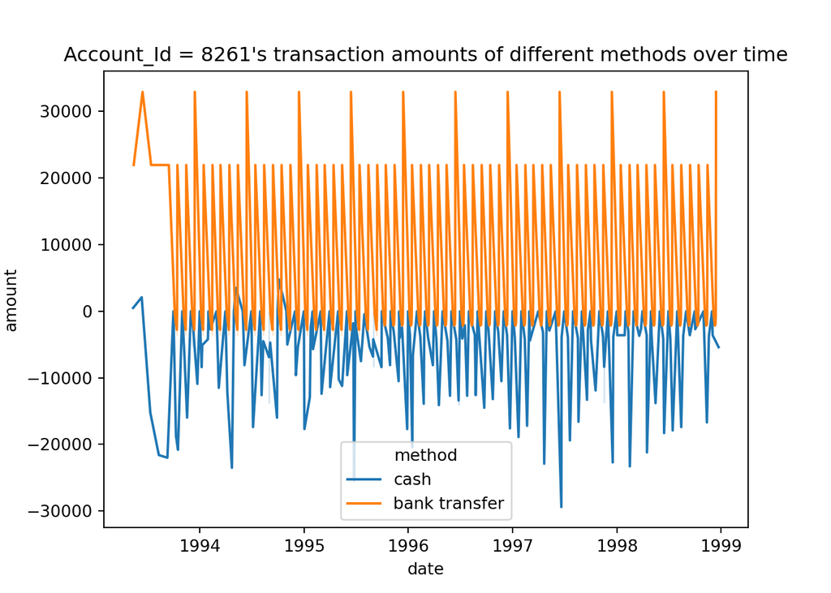

```python
plt.figure(6)
sns.lineplot(x=transactions.index, y=transactions['amount'], data=transactions, hue=transactions['method'])
plt.title("Account_Id = 8261's transaction amounts of different methods over time")
plt.show()
```

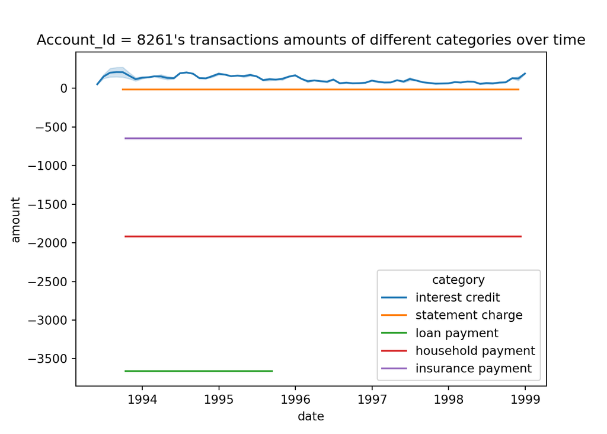

```python
plt.figure(7)
sns.lineplot(x=transactions.index, y=transactions['amount'], data=transactions, hue=transactions['category'])
plt.title("Account_Id = 8261's transactions amounts of different categories over time")
plt.show()
```